# Lab 3: Gesture Recognition using Convolutional Neural Networks

**Deadlines**:

Mon. Feb 14 at 5:00 PM (Part A)

Mon. Feb 28 at 5:00 PM (Part B)

**Late Penalty**: There is a penalty-free grace period of one hour past the deadline. Any work that is submitted between 1 hour and 24 hours past the deadline will receive a 20% grade deduction. No other late work is accepted. Quercus submission time will be used, not your local computer time. You can submit your labs as many times as you want before the deadline, so please submit often and early.

**Grading TAs**: Geoff Donoghue -- geoff.donoghue@mail.utoronto.ca

This lab is based on an assignment developed by Prof. Lisa Zhang.

This lab will be completed in two parts. In Part A you will you will gain experience gathering your own data set (specifically images of hand gestures), and understand the challenges involved in the data cleaning process. In Part B you will train a convolutional neural network to make classifications on different hand gestures. By the end of the lab, you should be able to:

1. Generate and preprocess your own data
2. Load and split data for training, validation and testing
3. Train a Convolutional Neural Network
4. Apply transfer learning to improve your model

Note that for this lab we will not be providing you with any starter code. You should be able to take the code used in previous labs, tutorials and lectures and modify it accordingly to complete the tasks outlined below.

### What to submit

**Submission for Part A:**  
Submit a zip file containing your images. Three images each of American Sign Language gestures for letters A - I (total of 27 images). You will be required to clean the images before submitting them. Details are provided under Part A of the handout.

Individual image file names should follow the convention of student-number_Alphabet_file-number.jpg (e.g. 100343434_A_1.jpg).

**Submission for Part B:**  
Submit a PDF file containing all your code, outputs, and write-up from parts 1-5. You can produce a PDF of your Google Colab file by going to **File > Print** and then save as PDF. The Colab instructions has more information. Make sure to review the PDF submission to ensure that your answers are easy to read. Make sure that your text is not cut off at the margins.

**Do not submit any other files produced by your code.**

Include a link to your colab file in your submission.

Please use Google Colab to complete this assignment. If you want to use Jupyter Notebook, please complete the assignment and upload your Jupyter Notebook file to Google Colab for submission.

## Colab Link

Include a link to your colab file here

Colab Link: https://colab.research.google.com/drive/1Hw6NTNlrGt_hJHMFMfNdP2Ef4845swBe?usp=sharing

## Part A. Data Collection [10 pt]

So far, we have worked with data sets that have been collected, cleaned, and curated by machine learning researchers and practitioners. Datasets like MNIST and CIFAR are often used as toy examples, both by students and by researchers testing new machine learning models.

In the real world, getting a clean data set is never that easy. More than half the work in applying machine learning is finding, gathering, cleaning, and formatting your data set.

The purpose of this lab is to help you gain experience gathering your own data set, and understand the challenges involved in the data cleaning process.

### American Sign Language

American Sign Language (ASL) is a complete, complex language that employs signs made by moving the hands combined with facial expressions and postures of the body. It is the primary language of many North Americans who are deaf and is one of several communication options used by people who are deaf or hard-of-hearing.

The hand gestures representing English alphabet are shown below. This lab focuses on classifying a subset of these hand gesture images using convolutional neural networks. Specifically, given an image of a hand showing one of the letters A-I, we want to detect which letter is being represented.

[figure not shown]

### Generating Data

We will produce the images required for this lab by ourselves. Each student will collect, clean and submit three images each of Americal Sign Language gestures for letters A - I (total of 27 images) Steps involved in data collection

1. Familiarize yourself with American Sign Language gestures for letters from A - I (9 letters).
2. Take three pictures at slightly different orientation for each letter gesture using your mobile phone.
   - Ensure adequate lighting while you are capturing the images.
   - Use a white wall as your background.
   - Use your right hand to create gestures (for consistency).
   - Keep your right hand fairly apart from your body and any other obstructions.
   - Avoid having shadows on parts of your hand.
3. Transfer the images to your laptop for cleaning.

### Cleaning Data

To simplify the machine learning the task, we will standardize the training images. We will make sure that all our images are of the same size (224 x 224 pixels RGB), and have the hand in the center of the cropped regions.

You may use the following applications to crop and resize your images:

**Mac**

- Use Preview: – Holding down CMD + Shift will keep a square aspect ratio while selecting the hand area. – Resize to 224x224 pixels.

**Windows 10**

- Use Photos app to edit and crop the image and keep the aspect ratio a square.
- Use Paint to resize the image to the final image size of 224x224 pixels.

**Linux**

- You can use GIMP, imagemagick, or other tools of your choosing. You may also use online tools such as http://picresize.com All the above steps are illustrative only. You need not follow these steps but following these will ensure that you produce a good quality dataset. You will be judged based on the quality of the images alone. Please do not edit your photos in any other way. You should not need to change the aspect ratio of your image. You also should not digitally remove the background or shadows—instead, take photos with a white background and minimal shadows.

### Accepted Images

Images will be accepted and graded based on the criteria below

1. The final image should be size 224x224 pixels (RGB).
2. The file format should be a .jpg file.
3. The hand should be approximately centered on the frame.
4. The hand should not be obscured or cut off.
5. The photos follows the ASL gestures posted earlier.
6. The photos were not edited in any other way (e.g. no electronic removal of shadows or background).

### Submission

Submit a zip file containing your images. There should be a total of 27 images (3 for each category)

1. Individual image file names should follow the convention of student-number_Alphabet_file-number.jpg (e.g. 100343434_A_1.jpg)
2. Zip all the images together and name it with the following convention: last-name_student-number.zip (e.g. last-name_100343434.zip).
3. Submit the zipped folder. We will be anonymizing and combining the images that everyone submits. We will announce when the combined data set will be available for download.

[figure not shown]

## Part B. Building a CNN [50 pt]

For this lab, we are not going to give you any starter code. You will be writing a convolutional neural network from scratch. You are welcome to use any code from previous labs, lectures and tutorials. You should also write your own code.

You may use the PyTorch documentation freely. You might also find online tutorials helpful. However, all code that you submit must be your own.

Make sure that your code is vectorized, and does not contain obvious inefficiencies (for example, unecessary for loops, or unnecessary calls to unsqueeze()). Ensure enough comments are included in the code so that your TA can understand what you are doing. It is your responsibility to show that you understand what you write.

**This is much more challenging and time-consuming than the previous labs.** Make sure that you give yourself plenty of time by starting early.

### 1. Data Loading and Splitting [5 pt]

Download the anonymized data provided on Quercus. To allow you to get a heads start on this project we will provide you with sample data from previous years. Split the data into training, validation, and test sets.

Note: Data splitting is not as trivial in this lab. We want our test set to closely resemble the setting in which our model will be used. In particular, our test set should contain hands that are never seen in training!

Explain how you split the data, either by describing what you did, or by showing the code that you used. Justify your choice of splitting strategy. How many training, validation, and test images do you have?

For loading the data, you can use plt.imread as in Lab 1, or any other method that you choose. You may find torchvision.datasets.ImageFolder helpful. (see https://pytorch.org/docs/stable/torchvision/datasets.html?highlight=image%20folder#torchvision.datasets.ImageFolder )

Importing required libraries

```python
import math
import pandas as pd
import numpy as np
import matplotlib.pyplot as plt
from matplotlib.pyplot import figure
```

```python
import torch
import torch.nn as nn
import torch.nn.functional as F
import torch.optim as optim
import torchvision
from torch.utils.data.sampler import SubsetRandomSampler
import torchvision.transforms as transforms
from torchvision.datasets import ImageFolder
from torch.utils.data.dataloader import DataLoader
```

```python
device = torch.device('cuda' if torch.cuda.is_available() else 'cpu')
device
```

```
device(type='cpu')
```

Mounting the google drive

```python
from google.colab import drive

drive.mount('/content/gdrive')
```

Loading the data

```python
dataset_path = "/content/gdrive/MyDrive/Lab3_Gestures_W22"
```

```python
import os
for folder in os.listdir(dataset_path):
    print(folder, ":", len(os.listdir(dataset_path + '/' + folder)))
```

```
I : 674
A : 668
D : 664
B : 666
C : 662
E : 662
H : 662
F : 674
G : 677
```

Dividing into train, val and test dataset with a given batch size

```python
batch_size = 20

dataset = ImageFolder(dataset_path,transform = transforms.Compose([
    transforms.ToTensor()
]))

# Split into train and validation
np.random.seed(1000) # Fixed numpy random seed for reproducible shuffling
relevant_train_indices = list(range(0, int(len(dataset))))
np.random.shuffle(relevant_train_indices)

val_split = int(len(relevant_train_indices) * 0.7)
test_split = int(len(relevant_train_indices) * 0.9)
relevant_train_indices, relevant_val_indices, relevant_test_indices = relevant_train_indices[:val_split], relevant_train_indices[val_split:test_split], relevant_train_indices[test_split:]

train_sampler = SubsetRandomSampler(relevant_train_indices)
train_loader = torch.utils.data.DataLoader(dataset, batch_size=batch_size,
                                           num_workers=1, sampler=train_sampler, pin_memory=True)

val_sampler = SubsetRandomSampler(relevant_val_indices)
val_loader = torch.utils.data.DataLoader(dataset, batch_size=batch_size,
                                          num_workers=1, sampler=val_sampler, pin_memory=True)

test_sampler = SubsetRandomSampler(relevant_test_indices)
test_loader = torch.utils.data.DataLoader(dataset, batch_size=batch_size,
                                             sampler=test_sampler, num_workers=1, pin_memory=True)

# The classes are encoded as follows: A-0, B-1, C-1, D-3, E-4, F-5, G-6, H-7, I-8
```

Defining a few helper functions

```python
def accuracy(output, labels):
    prob_list = F.softmax(output, dim=1)
    index = 0
    accuracy = 0
    for tensor in prob_list:
        temp_list = tensor.tolist()
        # print("---")
        # print(temp_list)
        max_num = 0
        max_index = 0
        for i in range(0, len(temp_list)):
            elem = temp_list[i]
            if elem > max_num:
                max_num = elem
                max_index = i
        if max_index == labels[index]:
            accuracy += 1
        index += 1

    return float(accuracy)/index * 100
```

```python
def evaluate(net, loader, criterion):
    """ Evaluate the network on the validation set.

     Args:
         net: PyTorch neural network object
         loader: PyTorch data loader for the validation set
         criterion: The loss function
     Returns:
         err: A scalar for the avg classification error over the validation set
         loss: A scalar for the average loss function over the validation set
     """
    total_loss = 0.0
    total_acc = 0.0
    total_epoch = 0
    for i, data in enumerate(loader, 0):
        inputs, labels = data
        inputs, labels = inputs.to(device), labels.to(device)

        outputs = net(inputs)
        loss = criterion(outputs, labels)
        total_acc += accuracy(outputs, labels)
        total_loss += loss.item()
        total_epoch += len(labels)
    acc = float(total_acc) / (i + 1)
    loss = float(total_loss) / (i + 1)
    return loss, acc
```

Visualizing data

```python
print("Training samples:", len(train_loader) * batch_size)

print("Validation samples:", len(val_loader) * batch_size)

print("Test samples:", len(test_loader) * batch_size)
```

```
Training samples: 4220
Validation samples: 1220
Test samples: 620
```

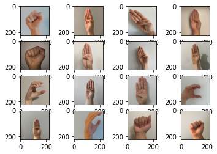

```python
num = 4
fig, axs = plt.subplots(4, num)

index = 0
for img, label in train_loader:
    img = img[0]
    img = img.permute(1, 2, 0)
    axs[int(index/num), int(index%num)].imshow(img)
    index += 1
    if index >= 4*num:
        break
```

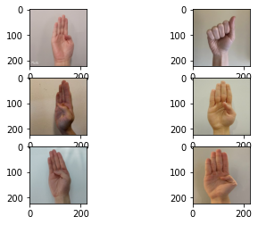

```python
num = 2
fig, axs = plt.subplots(3, num)

index = 0
for img, label in test_loader:
    img = img[0]
    img = img.permute(1, 2, 0)
    axs[int(index/num), int(index%num)].imshow(img)
    index += 1
    if index >= num*3:
        break
```

### 2. Model Building and Sanity Checking [15 pt]

### Part (a) Convolutional Network - 5 pt

Build a convolutional neural network model that takes the (224x224 RGB) image as input, and predicts the gesture letter. Your model should be a subclass of nn.Module. Explain your choice of neural network architecture: how many layers did you choose? What types of layers did you use? Were they fully-connected or convolutional? What about other decisions like pooling layers, activation functions, number of channels / hidden units?

```python
# Defining the CNN architechture
class Net(nn.Module):

    def __init__(self):
        super(Net, self).__init__()

        # 3 input image channel, 6 output channels, 5x5 square convolution
        self.conv1 = nn.Conv2d(3, 32, 5)
        self.conv2 = nn.Conv2d(32, 64, 5)
        self.fc1 = nn.Linear(64 * 53 * 53, 240)  # 53*53 from image dimension

        # The convolution decreases dimension by (W - f)/S + 1 and pooling reduces it by a factor of 2
        self.fc2 = nn.Linear(240, 128)

        # The last layer has 9 neurons for each of the 9 categories
        self.fc3 = nn.Linear(128, 9)

    def forward(self, x):
        # Max pooling over a (2, 2) window
        x = F.max_pool2d(F.relu(self.conv1(x)), (2, 2))
        # If the size is a square, you can specify with a single number
        x = F.max_pool2d(F.relu(self.conv2(x)), 2)
        x = torch.flatten(x, 1) # flatten all dimensions except the batch dimension
        x = F.relu(self.fc1(x))
        x = F.relu(self.fc2(x))
        x = self.fc3(x)
        return x

net = Net()
net.to(device) # transferring it to the gpu (if available)
print(net)
```

```
Net(
  (conv1): Conv2d(3, 32, kernel_size=(5, 5), stride=(1, 1))
  (conv2): Conv2d(32, 64, kernel_size=(5, 5), stride=(1, 1))
  (fc1): Linear(in_features=179776, out_features=240, bias=True)
  (fc2): Linear(in_features=240, out_features=128, bias=True)
  (fc3): Linear(in_features=128, out_features=9, bias=True)
)
```

### Part (b) Training Code - 5 pt

Write code that trains your neural network given some training data. Your training code should make it easy to tweak the usual hyperparameters, like batch size, learning rate, and the model object itself. Make sure that you are checkpointing your models from time to time (the frequency is up to you). Explain your choice of loss function and optimizer.

```python
num_epochs = 20

def train(net, num_epochs, log=True, learning_rate = 0.01, moment = 0.7, loss=False, l2=0):
    criterion = nn.CrossEntropyLoss()
    if l2:
        optimizer = optim.SGD(net.parameters(), lr=learning_rate, momentum=moment, weight_decay=l2)
    else:
        optimizer = optim.SGD(net.parameters(), lr=learning_rate, momentum=moment)

    train_loss = np.zeros(num_epochs)
    train_acc = np.zeros(num_epochs)

    val_loss = np.zeros(num_epochs)
    val_acc = np.zeros(num_epochs)

    for epoch in range(num_epochs):  # loop over the dataset multiple times
        total_train_loss = 0.0
        total_train_err = 0.0
        total_epoch = 0
        total_train_acc = 0.0

        for i, data in enumerate(train_loader, 0):
            # get the inputs; data is a list of [inputs, labels]
            inputs, labels = data
            inputs, labels = inputs.to(device), labels.to(device) # transferring it to the gpu

            # zero the parameter gradients
            optimizer.zero_grad()

            # forward + backward + optimize
            outputs = net(inputs)
            #print(outputs.shape, labels.shape)
            loss = criterion(outputs, labels)
            loss.backward()
            optimizer.step()

            # Calculate the statistics
            total_train_acc += accuracy(outputs, labels)
            total_train_loss += loss.item()
            total_epoch += len(labels)

        # train_err[epoch] = float(total_train_err) / total_epoch
        train_acc[epoch] = float(total_train_acc) / (i+1)
        train_loss[epoch] = float(total_train_loss) / (i+1)
        val_loss[epoch], val_acc[epoch] = evaluate(net, val_loader, criterion)

        if log:
            print(("Epoch {:.2f}: Train acc: {:.2f}, Train loss: {:.2f} |"+
                   "Val acc: {:.2f}, Val loss: {:.2f}").format(
                       epoch + 1,
                       train_acc[epoch],
                       train_loss[epoch],
                       val_acc[epoch],
                       val_loss[epoch]))

    print('Finished Training')
    print("Train acc:", train_acc[-1], " - Val acc:", val_acc[-1])
    print("---")
    if not loss:
        return [train_acc, val_acc]
    else:
        return [train_acc, val_acc, train_loss, val_loss]
```

### Part (c) “Overfit” to a Small Dataset - 5 pt

One way to sanity check our neural network model and training code is to check whether the model is capable of “overfitting” or “memorizing” a small dataset. A properly constructed CNN with correct training code should be able to memorize the answers to a small number of images quickly.

Construct a small dataset (e.g. just the images that you have collected). Then show that your model and training code is capable of memorizing the labels of this small data set.

With a large batch size (e.g. the entire small dataset) and learning rate that is not too high, You should be able to obtain a 100% training accuracy on that small dataset relatively quickly (within 200 iterations).

```python
batch_size = 20

dataset = ImageFolder(dataset_path,transform = transforms.Compose([
    transforms.ToTensor()
]))

# Split into train and validation
np.random.seed(1000) # Fixed numpy random seed for reproducible shuffling
relevant_train_indices = list(range(0, int(len(dataset)/20)))
np.random.shuffle(relevant_train_indices)

val_split = int(len(relevant_train_indices) * 0.7)
test_split = int(len(relevant_train_indices) * 0.9)
relevant_train_indices, relevant_val_indices, relevant_test_indices = relevant_train_indices[:val_split], relevant_train_indices[val_split:test_split], relevant_train_indices[test_split:]

train_sampler = SubsetRandomSampler(relevant_train_indices)
train_loader = torch.utils.data.DataLoader(dataset, batch_size=batch_size,
                                           num_workers=1, sampler=train_sampler, pin_memory=True)

val_sampler = SubsetRandomSampler(relevant_val_indices)
val_loader = torch.utils.data.DataLoader(dataset, batch_size=batch_size,
                                          num_workers=1, sampler=val_sampler, pin_memory=True)

test_sampler = SubsetRandomSampler(relevant_test_indices)
test_loader = torch.utils.data.DataLoader(dataset, batch_size=batch_size,
                                             num_workers=1,sampler=test_sampler, pin_memory=True)

# The classes are encoded as follows: A-0, B-1, C-1, D-3, E-4, F-5, G-6, H-7, I-8
```

Verifying the size of mini dataset

```python
print("Training samples:", len(train_loader) * batch_size)

print("Validation samples:", len(val_loader) * batch_size)

print("Test samples:", len(test_loader) * batch_size)
```

```
Training samples: 220
Validation samples: 60
Test samples: 40
```

Training on very small dataset

```python
tr_acc, val_acc = train(net, num_epochs, False, 0.1, 0.05)
```

```
Finished Training
Train acc: 100.0  - Val acc: 100.0
---
```

### 3. Hyperparameter Search [10 pt]

### Part (a) - 1 pt

List 3 hyperparameters that you think are most worth tuning. Choose at least one hyperparameter related to the model architecture.

- Learning Rate
- Momentum
- Kernel size / Regularization layer

### Part (b) - 5 pt

Tune the hyperparameters you listed in Part (a), trying as many values as you need to until you feel satisfied that you are getting a good model. Plot the training curve of at least 4 different hyperparameter settings.

Reloading the actual dataset

```python
batch_size = 20

dataset = ImageFolder(dataset_path,transform = transforms.Compose([
    transforms.ToTensor()
]))

# Split into train and validation
np.random.seed(1000) # Fixed numpy random seed for reproducible shuffling
relevant_train_indices = list(range(0, int(len(dataset))))
np.random.shuffle(relevant_train_indices)

val_split = int(len(relevant_train_indices) * 0.7)
test_split = int(len(relevant_train_indices) * 0.9)
relevant_train_indices, relevant_val_indices, relevant_test_indices = relevant_train_indices[:val_split], relevant_train_indices[val_split:test_split], relevant_train_indices[test_split:]

train_sampler = SubsetRandomSampler(relevant_train_indices)
train_loader = torch.utils.data.DataLoader(dataset, batch_size=batch_size,
                                           num_workers=1, sampler=train_sampler, pin_memory=True)

val_sampler = SubsetRandomSampler(relevant_val_indices)
val_loader = torch.utils.data.DataLoader(dataset, batch_size=batch_size,
                                          num_workers=1, sampler=val_sampler, pin_memory=True)

test_sampler = SubsetRandomSampler(relevant_test_indices)
test_loader = torch.utils.data.DataLoader(dataset, batch_size=batch_size,
                                             sampler=test_sampler, num_workers=1, pin_memory=True)

# The classes are encoded as follows: A-0, B-1, C-1, D-3, E-4, F-5, G-6, H-7, I-8
```

[output not shown]

[output cut: 377 more lines]

[output not shown]

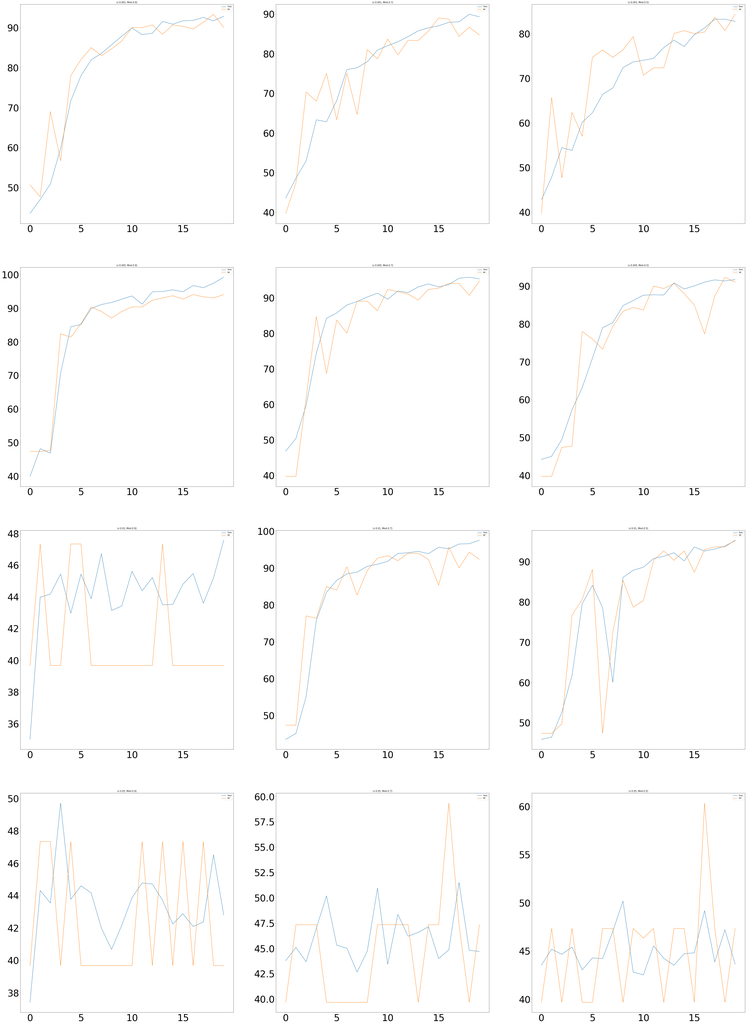

```python
# import warnings
# warnings.filterwarnings("ignore")

lrs = [0.001, 0.005, 0.01, 0.05]
moments = [0.9, 0.7, 0.5]
num_epochs = 20

col_lr = []
col_mmt = []
col_tr_acc = []
col_val_acc = []

x_axis = list(range(0, num_epochs))
fig, axs = plt.subplots(len(lrs), len(moments), figsize=(70, 100), dpi = 50)

i = 0
j = 0
for lr in lrs:
    j = 0
    for moment in moments:
        metric = train(net, num_epochs, log=True, learning_rate = lr, moment = moment, loss=False, l2=0)
        print(metric)
        tr_acc = metric[0]
        val_acc = metric[1]
        net = Net()
        net.to(device) # transferring it to the gpu

        col_lr.append(lr)
        col_mmt.append(moment)
        col_tr_acc.append(tr_acc[-1])
        col_val_acc.append(val_acc[-1])

        axs[i, j].tick_params(axis='both', which='major', labelsize=50)
        axs[i, j].tick_params(axis='both', which='minor', labelsize=50)
        axs[i, j]. plot(x_axis, tr_acc, label = "Train")
        axs[i, j].plot(x_axis, val_acc, label = "Val")
        axs[i, j].set_title('Lr:{}, Mmt:{}]'.format(lrs[i], moments[j]))
        axs[i, j].legend()
        j += 1
    i += 1
```

```python
d = {'Learning Rate': col_lr, 'Momentum': col_mmt, 'Train Acc': col_tr_acc, 'Val Acc': col_val_acc}
df = pd.DataFrame(data=d)

df.sort_values(by=['Val Acc'], ascending=False)
```

|  | Learning Rate | Momentum | Train Acc | Val Acc |
| --- | --- | --- | --- | --- |
| 8 | 0.010 | 0.5 | 95.205832 | 95.333333 |
| 4 | 0.005 | 0.7 | 95.283019 | 94.666667 |
| 3 | 0.005 | 0.9 | 99.168096 | 94.000000 |
| 7 | 0.010 | 0.7 | 97.564322 | 92.333333 |
| 5 | 0.005 | 0.5 | 91.732419 | 91.000000 |
| 0 | 0.001 | 0.9 | 92.830189 | 90.000000 |
| 1 | 0.001 | 0.7 | 89.279588 | 84.666667 |
| 2 | 0.001 | 0.5 | 82.735849 | 84.333333 |
| 10 | 0.050 | 0.7 | 44.691252 | 47.333333 |
| 11 | 0.050 | 0.5 | 43.627787 | 47.333333 |
| 6 | 0.010 | 0.9 | 47.572899 | 39.666667 |
| 9 | 0.050 | 0.9 | 42.795883 | 39.666667 |

### Part (c) - 2 pt

Choose the best model out of all the ones that you have trained. Justify your choice.

```python
# Final model based on the table above
train(net, 20, log=True, learning_rate = 0.01, moment = 0.5, loss=False, l2=0)
```

### Part (d) - 2 pt

Report the test accuracy of your best model. You should only do this step once and prior to this step you should have only used the training and validation data.

```python
test_loss, test_acc = evaluate(net, test_loader, nn.CrossEntropyLoss())
print(test_loss, test_acc)
```

```
1.02597928 90.62778730703259
```

### 4. Transfer Learning [15 pt]

For many image classification tasks, it is generally not a good idea to train a very large deep neural network model from scratch due to the enormous compute requirements and lack of sufficient amounts of training data.

One of the better options is to try using an existing model that performs a similar task to the one you need to solve. This method of utilizing a pre-trained network for other similar tasks is broadly termed **Transfer Learning**. In this assignment, we will use Transfer Learning to extract features from the hand gesture images. Then, train a smaller network to use these features as input and classify the hand gestures.

As you have learned from the CNN lecture, convolution layers extract various features from the images which get utilized by the fully connected layers for correct classification. AlexNet architecture played a pivotal role in establishing Deep Neural Nets as a go-to tool for image classification problems and we will use an ImageNet pre-trained AlexNet model to extract features in this assignment.

### Part (a) - 5 pt

Here is the code to load the AlexNet network, with pretrained weights. When you first run the code, PyTorch will download the pretrained weights from the internet.

```python
import torchvision.models
alexnet = torchvision.models.alexnet(pretrained=True)
```

The alexnet model is split up into two components: *alexnet.features* and *alexnet.classifier*. The first neural network component, *alexnet.features*, is used to compute convolutional features, which are taken as input in *alexnet.classifier*.

The neural network alexnet.features expects an image tensor of shape Nx3x224x224 as input and it will output a tensor of shape Nx256x6x6 . (N = batch size).

Compute the AlexNet features for each of your training, validation, and test data. Here is an example code snippet showing how you can compute the AlexNet features for some images (your actual code might be different):

```python
# img = ... a PyTorch tensor with shape [N,3,224,224] containing hand images ...
# features = alexnet.features(img)
```

**Save the computed features**. You will be using these features as input to your neural network in Part (b), and you do not want to re-compute the features every time. Instead, run *alexnet.features* once for each image, and save the result.

Creating directory structure

```python
import os

os.chdir('/content/gdrive/MyDrive/Lab3_Gestures_W22/alexnet_labels')

for folder in os.listdir('/content/gdrive/MyDrive/Lab3_Gestures_W22/'):
  if (folder != 'alexnet_labels'):
    os.mkdir(folder)
```

```python
# Saving the feature files
from PIL import Image
main_path = '/content/gdrive/MyDrive/Lab3_Gestures_W22/'
feature_path = '/content/gdrive/MyDrive/alexnet_labels'

transform = transforms.ToTensor()

for folder in os.listdir(main_path):
  for img in os.listdir(main_path + '/' + folder):
    im = Image.open(main_path + '/' + folder + '/' + img)
    image = transform(im)
    image = image.unsqueeze(0)

    features = alexnet.features(image)
    torch.save(features, (feature_path + '/' + folder + '/' + img[:-4] + '.pt'))
```

### Part (b) - 3 pt

Build a convolutional neural network model that takes as input these AlexNet features, and makes a prediction. Your model should be a subclass of nn.Module.

Explain your choice of neural network architecture: how many layers did you choose? What types of layers did you use: fully-connected or convolutional? What about other decisions like pooling layers, activation functions, number of channels / hidden units in each layer?

Here is an example of how your model may be called:

```python
import os
feature_path = '/content/gdrive/MyDrive/alexnet_labels'

labels = {'A':0, 'B':1, 'C':2, 'D':3, 'E':4, 'F':5, 'G':6, 'H':7, 'I':8}

feature_data = {}

for folder in os.listdir(feature_path):
  if (len(folder) == 1):
    for feat in os.listdir(feature_path + '/' + folder):
      if (feat != '.ipynb_checkpoints'):
        data = torch.load(feature_path + '/' + folder + '/' + feat)
        if labels[folder] in feature_data:
          feature_data[labels[folder]].append(data)
        else:
          feature_data[labels[folder]] = [data]

print('Features extracted')
```

```
Features extracted
```

```python
for keys, value in feature_data.items():
  print(keys, len(value))
```

```
8 674
0 668
3 664
1 666
2 662
4 662
7 662
5 674
6 677
```

```python
# Defining the CNN architechture
class ANet(nn.Module):

    def __init__(self):
        super(ANet, self).__init__()

        # 3 input image channel, 6 output channels, 5x5 square convolution
        self.conv1 = nn.Conv2d(256, 512, 3)
        # The convolution decreases dimension by (W - f)/S + 1 and pooling reduces it by a factor of 2

        self.fc1 = nn.Linear(512 * 2 * 2, 64)  # 2*2 from image dimension
        self.fc2 = nn.Linear(64, 9)
        # The last layer has 9 neurons for each of the 9 categories

    def forward(self, x):
        # Max pooling over a (2, 2) window
        x = F.max_pool2d(F.relu(self.conv1(x)), (2, 2))
        x = torch.flatten(x, 1) # flatten all dimensions except the batch dimension
        x = F.relu(self.fc1(x))
        #x = F.relu(self.fc2(x))
        x = self.fc2(x)
        return x

anet = ANet()
anet.to(device) # transferring it to the gpu (if available)
print(anet)
```

```
ANet(
  (conv1): Conv2d(256, 512, kernel_size=(3, 3), stride=(1, 1))
  (fc1): Linear(in_features=2048, out_features=64, bias=True)
  (fc2): Linear(in_features=64, out_features=9, bias=True)
)
```

```python
train_data = []
val_data = []
test_data = []

for keys, value in feature_data.items():

  for i in range(int(len(value)*0.7)):
    train_data.append([value[i], keys])

  for i in range(int(len(value)*0.7), int(len(value)*0.9)):
    val_data.append([value[i], keys])

  for i in range(int(len(value)*0.9), int(len(value))):
    test_data.append([value[i], keys])

print("Verifying")
print(len(train_data), len(val_data), len(test_data))
```

```
Verifying
4201 1202 606
```

### Part (c) - 5 pt

Train your new network, including any hyperparameter tuning. Plot and submit the training curve of your best model only.

Note: Depending on how you are caching (saving) your AlexNet features, PyTorch might still be tracking updates to the **AlexNet weights**, which we are not tuning. One workaround is to convert your AlexNet feature tensor into a numpy array, and then back into a PyTorch tensor.

```python
def accuracy(output, labels):
    prob_list = F.softmax(output, dim=1)
    temp_list = prob_list[0].tolist()

    # print("---")
    # print(temp_list, "LABEL:", labels[0].tolist())
    max_num = 0
    max_index = 0
    for i in range(0, len(temp_list)):
        elem = temp_list[i]
        if elem > max_num:
            max_num = elem
            max_index = i
    if max_index == labels[0].tolist():
        return 1

    #print(temp_list, "<->", max_index, "<->", labels)

    #print(max_index, labels)
    return 0
```

```python
def evaluate(anet, loader, criterion):

    total_loss = 0.0
    total_acc = 0.0
    i = 0
    for elem in loader:
        # print(elem[0].shape, elem[1].shape)
        inputs, labels = elem[0], torch.tensor([elem[1]])
        # inputs, labels = inputs.to(device), labels.to(device)

        outputs = anet(inputs)
        loss = criterion(outputs, labels)
        total_acc += accuracy(outputs, labels)
        total_loss += loss.item()
        i += 1

    acc = float(total_acc) / (i+1)
    loss = float(total_loss) / (i+1)
    return loss, acc
```

```python
num_epochs = 100

def train(net, num_epochs, log=True, learning_rate = 0.001, moment = 0.8, loss=False, l2=0):
    criterion = nn.CrossEntropyLoss()
    if l2:
        optimizer = optim.SGD(net.parameters(), lr=learning_rate, momentum=moment, weight_decay=l2)
    else:
        optimizer = optim.SGD(net.parameters(), lr=learning_rate, momentum = moment)

    train_loss = np.zeros(num_epochs)
    train_acc = np.zeros(num_epochs)

    val_loss = np.zeros(num_epochs)
    val_acc = np.zeros(num_epochs)

    for epoch in range(num_epochs):  # loop over the dataset multiple times
        total_train_loss = 0.0
        total_train_err = 0.0
        total_train_acc = 0.0

        for elem in train_data:
            # get the inputs; data is a list of [inputs, labels]
            inputs, labels = elem[0], torch.tensor([elem[1]])
            # inputs, labels = inputs.to(device), labels.to(device) # transferring it to the gpu

            # forward + backward + optimize
            outputs = net(inputs)

            #print(inputs.shape, outputs.shape, labels.shape)

            loss = criterion(outputs, labels)
            loss.backward()
            optimizer.step()

            # zero the parameter gradients
            optimizer.zero_grad()

        val_loss[epoch], val_acc[epoch] = evaluate(anet, val_data, criterion)
        train_loss[epoch], train_acc[epoch] = evaluate(anet, train_data, criterion)

        if log:
            print(("Epoch {:.2f}: Train acc: {:.2f}, Train loss: {:.2f} |"+
                   "Val acc: {:.2f}, Val loss: {:.2f}").format(
                       epoch + 1,
                       train_acc[epoch],
                       train_loss[epoch],
                       val_acc[epoch],
                       val_loss[epoch]))

    print('Finished Training')
    print("Train acc:", train_acc[-1], " - Val acc:", val_acc[-1])
    print("---")
    if not loss:
        return [train_acc, val_acc]
    else:
        return [train_acc, val_acc, train_loss, val_loss]

anet = ANet()
train(anet, num_epochs, log=True, learning_rate = 0.001, moment = 0.8, loss=False, l2=0)
```

```
Epoch 1.00: Train acc: 0.11, Train loss: 6.61 |Val acc: 0.11, Val loss: 6.68
Epoch 2.00: Train acc: 0.11, Train loss: 6.33 |Val acc: 0.11, Val loss: 6.37
Epoch 3.00: Train acc: 0.11, Train loss: 5.96 |Val acc: 0.11, Val loss: 6.00
Epoch 4.00: Train acc: 0.11, Train loss: 5.78 |Val acc: 0.11, Val loss: 5.85
Epoch 5.00: Train acc: 0.12, Train loss: 4.87 |Val acc: 0.12, Val loss: 4.95
Epoch 6.00: Train acc: 0.20, Train loss: 4.94 |Val acc: 0.19, Val loss: 4.97
Epoch 7.00: Train acc: 0.20, Train loss: 4.43 |Val acc: 0.19, Val loss: 4.48
Epoch 8.00: Train acc: 0.20, Train loss: 4.50 |Val acc: 0.19, Val loss: 4.53
Epoch 9.00: Train acc: 0.21, Train loss: 4.91 |Val acc: 0.19, Val loss: 4.93
Epoch 10.00: Train acc: 0.21, Train loss: 5.51 |Val acc: 0.21, Val loss: 5.51
Epoch 11.00: Train acc: 0.21, Train loss: 5.70 |Val acc: 0.20, Val loss: 5.69
Epoch 12.00: Train acc: 0.21, Train loss: 6.14 |Val acc: 0.20, Val loss: 6.05
Epoch 13.00: Train acc: 0.21, Train loss: 6.65 |Val acc: 0.20, Val loss: 6.64
Epoch 14.00: Train acc: 0.22, Train loss: 7.93 |Val acc: 0.21, Val loss: 7.98
Epoch 15.00: Train acc: 0.22, Train loss: 8.12 |Val acc: 0.21, Val loss: 8.16
Epoch 16.00: Train acc: 0.22, Train loss: 8.59 |Val acc: 0.21, Val loss: 8.59
Epoch 17.00: Train acc: 0.24, Train loss: 7.35 |Val acc: 0.23, Val loss: 7.40
Epoch 18.00: Train acc: 0.27, Train loss: 6.61 |Val acc: 0.26, Val loss: 6.65
Epoch 19.00: Train acc: 0.28, Train loss: 7.55 |Val acc: 0.27, Val loss: 7.53
Epoch 20.00: Train acc: 0.28, Train loss: 7.54 |Val acc: 0.29, Val loss: 7.60
Epoch 21.00: Train acc: 0.28, Train loss: 7.33 |Val acc: 0.28, Val loss: 7.36
Epoch 22.00: Train acc: 0.37, Train loss: 6.21 |Val acc: 0.37, Val loss: 6.25
Epoch 23.00: Train acc: 0.40, Train loss: 4.48 |Val acc: 0.41, Val loss: 4.51
Epoch 24.00: Train acc: 0.38, Train loss: 5.22 |Val acc: 0.39, Val loss: 5.46
Epoch 25.00: Train acc: 0.40, Train loss: 4.69 |Val acc: 0.39, Val loss: 4.78
Epoch 26.00: Train acc: 0.39, Train loss: 4.13 |Val acc: 0.37, Val loss: 4.27
Epoch 27.00: Train acc: 0.44, Train loss: 4.43 |Val acc: 0.42, Val loss: 4.90
Epoch 28.00: Train acc: 0.45, Train loss: 4.12 |Val acc: 0.44, Val loss: 4.65
Epoch 29.00: Train acc: 0.47, Train loss: 4.25 |Val acc: 0.41, Val loss: 4.93
Epoch 30.00: Train acc: 0.54, Train loss: 2.90 |Val acc: 0.46, Val loss: 3.58
Epoch 31.00: Train acc: 0.61, Train loss: 2.21 |Val acc: 0.56, Val loss: 2.98
Epoch 32.00: Train acc: 0.67, Train loss: 1.60 |Val acc: 0.58, Val loss: 2.45
Epoch 33.00: Train acc: 0.63, Train loss: 1.88 |Val acc: 0.61, Val loss: 2.71
Epoch 34.00: Train acc: 0.73, Train loss: 1.01 |Val acc: 0.66, Val loss: 1.97
Epoch 35.00: Train acc: 0.79, Train loss: 0.97 |Val acc: 0.68, Val loss: 1.77
Epoch 36.00: Train acc: 0.74, Train loss: 1.58 |Val acc: 0.61, Val loss: 2.53
Epoch 37.00: Train acc: 0.73, Train loss: 2.32 |Val acc: 0.62, Val loss: 3.24
Epoch 38.00: Train acc: 0.71, Train loss: 2.61 |Val acc: 0.61, Val loss: 3.49
Epoch 39.00: Train acc: 0.81, Train loss: 1.09 |Val acc: 0.69, Val loss: 2.12
Epoch 40.00: Train acc: 0.79, Train loss: 1.18 |Val acc: 0.65, Val loss: 2.28
```

[output cut: 48 more lines]

```
Epoch 89.00: Train acc: 1.00, Train loss: 0.00 |Val acc: 0.89, Val loss: 0.84
Epoch 90.00: Train acc: 1.00, Train loss: 0.00 |Val acc: 0.89, Val loss: 0.84
Epoch 91.00: Train acc: 1.00, Train loss: 0.00 |Val acc: 0.89, Val loss: 0.84
Epoch 92.00: Train acc: 1.00, Train loss: 0.00 |Val acc: 0.89, Val loss: 0.84
Epoch 93.00: Train acc: 1.00, Train loss: 0.00 |Val acc: 0.89, Val loss: 0.84
Epoch 94.00: Train acc: 1.00, Train loss: 0.00 |Val acc: 0.89, Val loss: 0.84
Epoch 95.00: Train acc: 1.00, Train loss: 0.00 |Val acc: 0.89, Val loss: 0.84
Epoch 96.00: Train acc: 1.00, Train loss: 0.00 |Val acc: 0.89, Val loss: 0.84
Epoch 97.00: Train acc: 1.00, Train loss: 0.00 |Val acc: 0.89, Val loss: 0.84
Epoch 98.00: Train acc: 1.00, Train loss: 0.00 |Val acc: 0.89, Val loss: 0.85
Epoch 99.00: Train acc: 1.00, Train loss: 0.00 |Val acc: 0.89, Val loss: 0.85
Epoch 100.00: Train acc: 1.00, Train loss: 0.00 |Val acc: 0.89, Val loss: 0.85
Finished Training
Train acc: 0.9976076555023924  - Val acc: 0.8907563025210085
---
```

[output not shown]

[output cut: 30 more lines]

[output not shown]

### Part (d) - 2 pt

Report the test accuracy of your best model. How does the test accuracy compare to Part 3(d) without transfer learning?

I experimented with different layer numbers and hidden units and with and without L2 regularizations. The best accuracy achieved was: 99% training and 90% validation.

```python
criterion = nn.CrossEntropyLoss()

total_loss = 0.0
total_acc = 0.0
for elem in test_data:
    # print(elem[0].shape, elem[1].shape)
    inputs, labels = elem[0], torch.tensor([elem[1]])
    # inputs, labels = inputs.to(device), labels.to(device)

    outputs = anet(inputs)
    loss = criterion(outputs, labels)
    total_acc += accuracy(outputs, labels)
    total_loss += loss.item()

acc = float(total_acc) / len(test_data)
loss = float(total_loss) / len(test_data)
print(loss, acc)
```

[output not shown]

This is very similar to the test accuracy obtained from our custom model

### 5. Additional Testing [5 pt]

As a final step in testing we will be revisiting the sample images that you had collected and submitted at the start of this lab. These sample images should be untouched and will be used to demonstrate how well your model works at identifying your hand guestures.

Using the best transfer learning model developed in Part 4. Report the test accuracy on your sample images and how it compares to the test accuracy obtained in Part 4(d)? How well did your model do for the different hand guestures? Provide an explanation for why you think your model performed the way it did?